# week_11_wederstrandt_d

David Wederstrandt

2026-06-28

```r
knitr::opts_chunk$set(echo=FALSE)
```

# Housing Prices

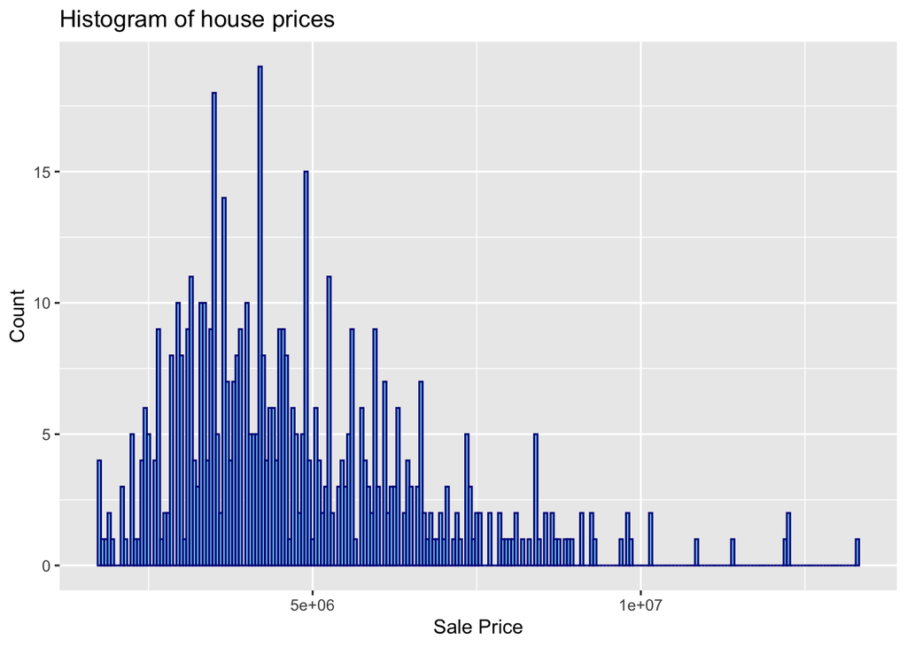

[output not shown]

[output cut: 313 more lines]

[output not shown]

I can see the price is right skewed, which can make it difficult to make assumptions about.

## Explain any transformations or modifications you made to the dataset.

The price data is right-skewed so I will transform this column I will take the log of price to create a normal(ish) distibution.

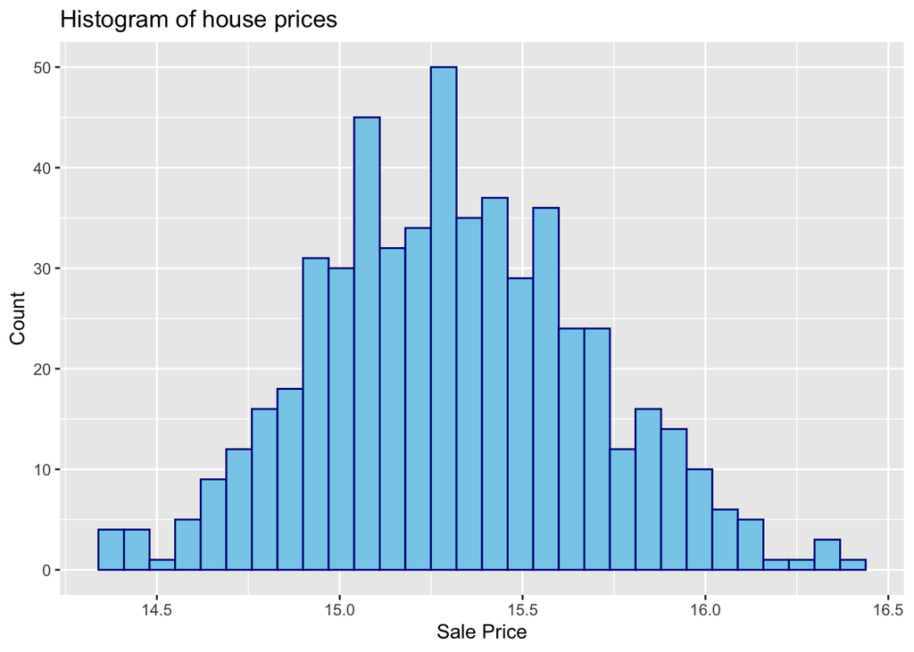

[output not shown]

[output cut: 313 more lines]

[output not shown]

Using the log of price, we now have a normal distribution, but not perfectly normal

## Linear Model Results

```
##
## The R-squared of 0.2951017 or 29.5% of the variation in price can be explained by area.
```

```
##
##
## The adjusted R-squared of 0.2938035  or 29.3%, tells us that sill only 29% of the variation can be explained by
## area, even after accounting foe the number of predictors.
```

```
##
##
## The RMSE of 0.3121765 tells us that, on average, the predictors differ from observed data.
```

```
##
##
## The MSE of 0.09745415 means that, on average, the squared differences between the model's predicted prices and
## and actual prices are close to 0.09 units squared.
```

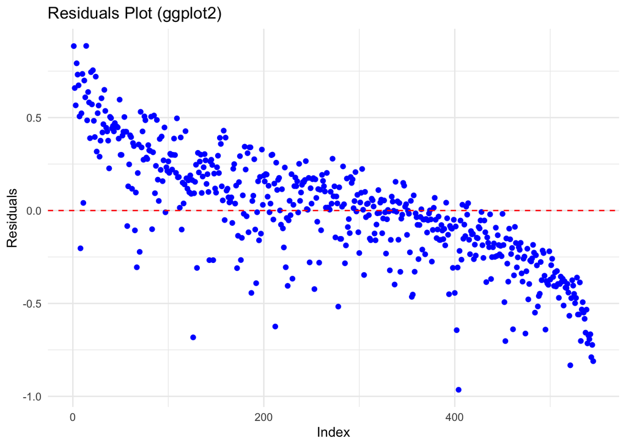

You can clearly see a pattern, which suggest that the relationship between area and log(price) may mot be perfectly linear. So, this model would not be appropriate for this data.

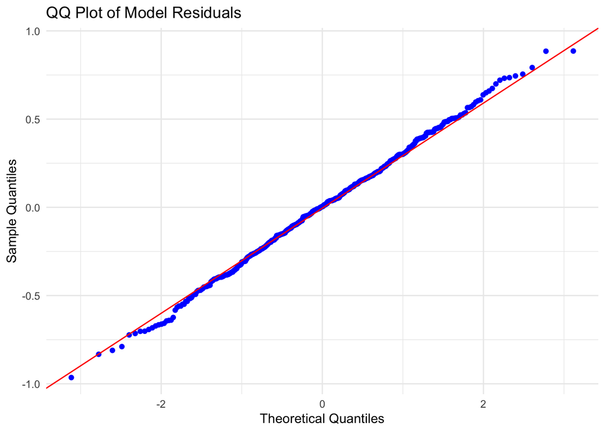

Almost all point fall directly on the red line, which tells us the residuals are approximately normal This supports the use of linear regression

## Multiple Predictor Linear Regression Model

### Multiple Predictors and Reasoning

| Category | Reasoning |
| --- | --- |
| *Area* | Most realators values homes at so many dollars per square foot. Bigger houses sell for more money. |
| *Bedrooms* | More bathrooms are more appealing to families. |
| *Bathrooms* | More bathrooms add convenience, thus value. |
| *stories* | More stories require less land to make a larger home. |
| *parking* | Small parking areas require more management, while more parking is easier to manage |
| *airconditioning* | Depending on location, air conditioning is practically an essential |

## Multiple Regressor Summary

```
##
## Call:
## lm(formula = Log_SalePrice ~ area + bedrooms + bathrooms + stories +
##     parking + airconditioning, data = housing)
##
## Residuals:
##      Min       1Q   Median       3Q      Max
## -0.71353 -0.15468  0.01021  0.15679  0.74506
##
## Coefficients:
##                     Estimate Std. Error t value Pr(>|t|)
## (Intercept)        1.437e+01  4.774e-02 300.980  < 2e-16 ***
## area               6.234e-05  5.187e-06  12.019  < 2e-16 ***
## bedrooms           4.263e-02  1.597e-02   2.670  0.00781 **
## bathrooms          1.866e-01  2.291e-02   8.144 2.68e-15 ***
## stories            8.268e-02  1.367e-02   6.050 2.72e-09 ***
## parking            6.077e-02  1.290e-02   4.710 3.16e-06 ***
## airconditioningyes 1.877e-01  2.374e-02   7.908 1.49e-14 ***
## ---
## Signif. codes:  0 '***' 0.001 '**' 0.01 '*' 0.05 '.' 0.1 ' ' 1
##
## Residual standard error: 0.2395 on 538 degrees of freedom
## Multiple R-squared:  0.5903, Adjusted R-squared:  0.5857
## F-statistic: 129.2 on 6 and 538 DF,  p-value: < 2.2e-16
```

### Results

```
##
## The coefficients show the estimated effect of each predictor on log(price), holding other variables constant.
```

```
##
## The R-squared and adjusted R-squared values indicate how much of the variation in log(sale price) is explained by the model.
```

```
##
## Significant p-values (Pr(>|t|)) for predictors suggest those variables have a statistically significant association with log(sale price).
```

```
##
## Compare these values to the single-predictor model to assess improvement.
```

### Second Model’ Residuals

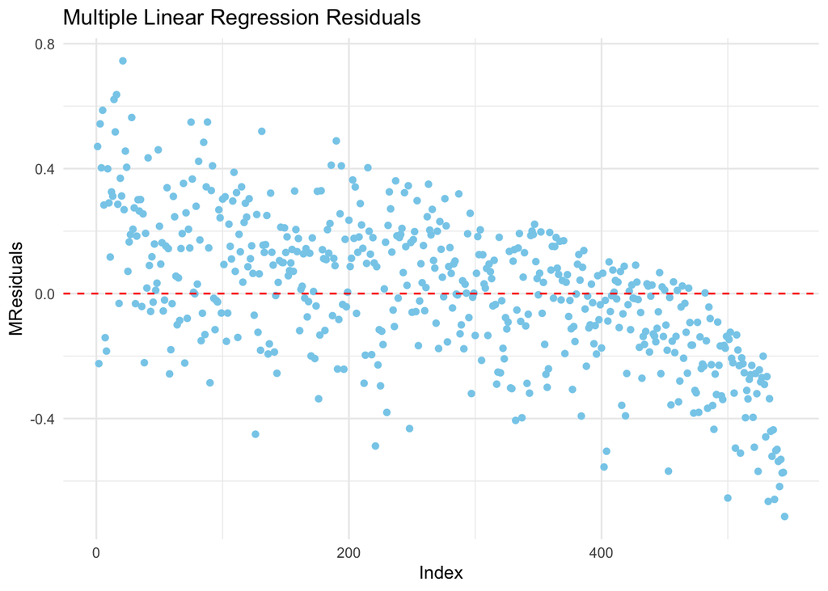

You can clearly see a pattern, which suggest that the relationship between area and log(price) may not be perfectly linear. Just like the residuals for the single residual. So, this model would not be appropriate for this data.

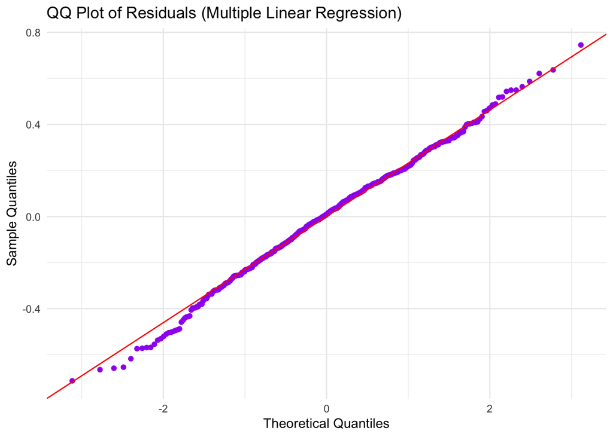

Almost all point fall directly on the red line as they did with just area, which tells us the residuals are approximately normal. This supports the use of linear regression

```
## First Model (area only):
##  R-squared: 0.2951017
##  Adjusted R-squared: 0.2938035
##  RMSE: 0.3121765
##  MSE: 0.09745415
```

```
## Second Model (multiple predictors):
##  R-squared: 0.5902653
##  Adjusted R-squared: 0.5856957
##  RMSE: 0.2380062
##  MSE: 0.05664696
```

```
##
##
##
## Multiple regression model(MRM) R-squared: 0.5902653 is greater than Area regression model (ARM) R-squared: 0.2951017 and
```

```
##
## MRM Adjusted R-squared: 0.5856957 is greater than ARMl R-squared: 0.2938035 .
```

```
##
##  Meaning: MRM explains more of the variation in log(price) than the ARM.
```

```
##
##
##
## Multiple regression model(MRM) Root Mean Squared Error (RMSE) : 0.2380062 is less than Area regression model (ARM) RMSE: 0.3121765 and
```

```
##
## MRM Mean Squared Error (MSE): 0.05664696 is less than ARMl Mean Squared Error (MSE): 0.09745415 .
```

```
##
##  Meaning: MRM RMSE and MSE are less indicating MRM predictions are, on average, closer to the actual values.
```

```
## Analysis of Variance Table
##
## Model 1: Log_SalePrice ~ area
## Model 2: Log_SalePrice ~ area + bedrooms + bathrooms + stories + parking +
##     airconditioning
##   Res.Df    RSS Df Sum of Sq      F    Pr(>F)
## 1    543 53.113
## 2    538 30.873  5     22.24 77.513 < 2.2e-16 ***
## ---
## Signif. codes:  0 '***' 0.001 '**' 0.01 '*' 0.05 '.' 0.1 ' ' 1
```

[output not shown]